# HW6

Prevalence of Other Risk Factors in People with Heart Disease

Rhowena Vespa  
1/16/2022

### INTRODUCTION

According to the CDC, heart disease is the leading cause of death in the US, followed by cancer and Covid-19 in 2020. As such, unlike my initial homework submissions which was focused on the “stroke” variable, I have decided to concentrate on the prevalence of heart disease for this final paper. This research involves analysis of “Stroke Prediction Dataset” from Kaggle. The dataset has 5110 observations consisting of binary and continuous variables of risk factors for heart disease such as hypertension, obesity, diabetes, and smoking among others. Using the data set, this research aims to establish correlations between the prevalence of the different risk factors in patients who have heart disease. The CDC also states that adults age 45-54 have the highest prevalence of obesity (38.1%) while adults age 18-24 have the lowest prevalence (19.5%) in the US. I would like to compare this information with this data set.

### RESEARCH QUESTIONS

1. What significant risk factors are prevalent in people with heart disease?
2. Are people who formerly smoked less likely to also have heart disease than smokers?
3. Are older people more likely to have obesity and have diabetes?

### DATA

1. Read CSV file into R

```r
library(distill)
library(dplyr)
library(readr)
library(tidyverse)
Stroke<- read.csv('healthcare-dataset-stroke-data.csv',TRUE,',',na.strings = "N/A")
class(Stroke)
```

```
[1] "data.frame"
```

```r
colnames(Stroke)
```

```
 [1] "id"                "gender"            "age"
 [4] "hypertension"      "heart_disease"     "ever_married"
 [7] "work_type"         "Residence_type"    "avg_glucose_level"
[10] "bmi"               "smoking_status"    "stroke"
```

```r
dim(Stroke)
```

```
[1] 5110   12
```

The dataset consisted of people from infant (age=0) to age 82. This research will focus on the prevalence of risk factors on ADULT patients with heart disease. The dataset will first be filtered to exclude data on children (age < 18) and patient ID. The binary variables that have values of 1 =yes and 0=No are hypertension, heart disease and stroke; gender is “male” or “female”, ever married is “yes” or “no”, residence type is “urban” or “rural”. Other categorical variables are work type and smoking status, Numerical variables are age, body mass index (bmi) and avg glucose levels.

As with most available medical datasets, there is an imbalance in their class labels. As such, explanations and predictability of data is difficult to interpret. The dataset from Kaggle also has an imbalance class problem (Figure 1)

```r
AdultStroke<- filter(Stroke, age>=18) #Filter out children age 0-17
head(AdultStroke)
```

```
     id gender age hypertension heart_disease ever_married
1  9046   Male  67            0             1          Yes
2 51676 Female  61            0             0          Yes
3 31112   Male  80            0             1          Yes
4 60182 Female  49            0             0          Yes
5  1665 Female  79            1             0          Yes
6 56669   Male  81            0             0          Yes
      work_type Residence_type avg_glucose_level  bmi  smoking_status
1       Private          Urban            228.69 36.6 formerly smoked
2 Self-employed          Rural            202.21   NA    never smoked
3       Private          Rural            105.92 32.5    never smoked
4       Private          Urban            171.23 34.4          smokes
5 Self-employed          Rural            174.12 24.0    never smoked
6       Private          Urban            186.21 29.0 formerly smoked
  stroke
1      1
2      1
3      1
4      1
5      1
6      1
```

```r
AdultStroke1<-select(AdultStroke,-c(id))
```

```r
HD<-mutate(AdultStroke1, heart_disease = recode(heart_disease, `1` = "Yes", `0` = "No"))
```

```r
HD %>%
  count(heart_disease, sort = TRUE) %>%
  head(4)
```

```
  heart_disease    n
1            No 3979
2           Yes  275
```

#### Figure 1 - Imbalance dataset

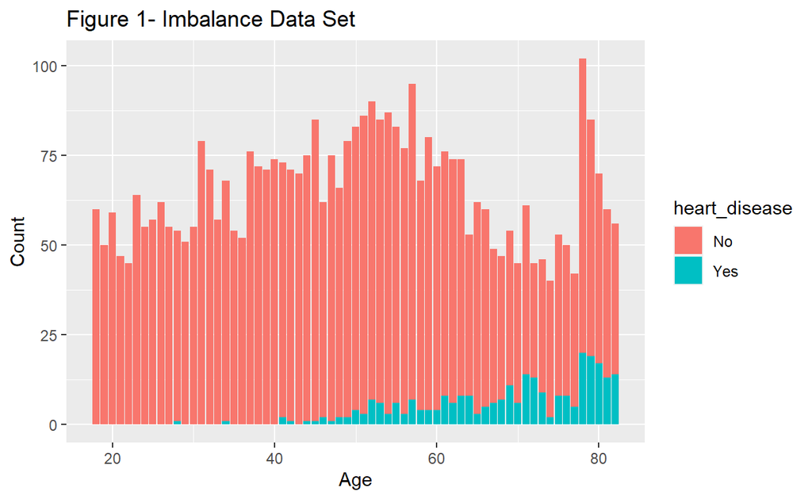

```r
ggplot(HD, aes(x=age, fill=heart_disease))+
  geom_bar() +
  labs(x="Age", y="Count", title = "Figure 1- Imbalance Data Set")
```

#### Understand data with descriptive statistics

```r
HD$heart_disease <- as.factor(HD$heart_disease)
summary(HD)
```

```
    gender               age        hypertension    heart_disease
 Length:4254        Min.   :18.0   Min.   :0.0000   No :3979
 Class :character   1st Qu.:36.0   1st Qu.:0.0000   Yes: 275
 Mode  :character   Median :50.5   Median :0.0000
                    Mean   :50.2   Mean   :0.1168
                    3rd Qu.:64.0   3rd Qu.:0.0000
                    Max.   :82.0   Max.   :1.0000

 ever_married        work_type         Residence_type
 Length:4254        Length:4254        Length:4254
 Class :character   Class :character   Class :character
 Mode  :character   Mode  :character   Mode  :character




 avg_glucose_level      bmi        smoking_status
 Min.   : 55.12    Min.   :11.30   Length:4254
 1st Qu.: 77.48    1st Qu.:25.40   Class :character
 Median : 92.47    Median :29.20   Mode  :character
 Mean   :108.51    Mean   :30.43
 3rd Qu.:116.14    3rd Qu.:34.20
 Max.   :271.74    Max.   :92.00
                   NA's   :181
     stroke
 Min.   :0.00000
 1st Qu.:0.00000
 Median :0.00000
 Mean   :0.05806
 3rd Qu.:0.00000
 Max.   :1.00000
```

### BALANCE THE DATASET

```r
set.seed(123) #partition into train and test data
ind <- sample(2, nrow(AdultStroke1), replace = TRUE, prob = c(0.7, 0.3))
train <- AdultStroke1[ind==1,]
test <- AdultStroke1[ind==2,]
```

```r
table(train$heart_disease) #classification predictive model data on training set
```

```
   0    1
2777  199
```

```r
prop.table(table(train$heart_disease))
```

```
         0          1
0.93313172 0.06686828
```

```r
summary(train)
```

```
    gender               age         hypertension  heart_disease
 Length:2976        Min.   :18.00   Min.   :0.00   Min.   :0.00000
 Class :character   1st Qu.:37.00   1st Qu.:0.00   1st Qu.:0.00000
 Mode  :character   Median :51.00   Median :0.00   Median :0.00000
                    Mean   :50.59   Mean   :0.12   Mean   :0.06687
                    3rd Qu.:64.00   3rd Qu.:0.00   3rd Qu.:0.00000
                    Max.   :82.00   Max.   :1.00   Max.   :1.00000

 ever_married        work_type         Residence_type
 Length:2976        Length:2976        Length:2976
 Class :character   Class :character   Class :character
 Mode  :character   Mode  :character   Mode  :character




 avg_glucose_level      bmi       smoking_status
 Min.   : 55.12    Min.   :11.3   Length:2976
 1st Qu.: 77.31    1st Qu.:25.5   Class :character
 Median : 92.91    Median :29.1   Mode  :character
 Mean   :108.85    Mean   :30.3
 3rd Qu.:116.02    3rd Qu.:34.0
 Max.   :267.60    Max.   :78.0
                   NA's   :127
     stroke
 Min.   :0.00000
 1st Qu.:0.00000
 Median :0.00000
 Mean   :0.06082
 3rd Qu.:0.00000
 Max.   :1.00000
```

#### Predictive Model using Random Forest

```r
library(ROSE)
library(randomForest)
library(caret)
library(e1071)
```

```r
rftrain <- randomForest(heart_disease~.,data = train, na.action=na.omit)
print(rftrain)
```

```
Call:
 randomForest(formula = heart_disease ~ ., data = train, na.action = na.omit)
               Type of random forest: regression
                     Number of trees: 500
No. of variables tried at each split: 3

          Mean of squared residuals: 0.05386863
                    % Var explained: 6.56
```

### BALANCED DATA by oversampling is now HDover (see Figure 2)

```r
HDover <- ovun.sample(heart_disease~., data = train, method = "over", N = 5340)$data
```

```r
summary(HDover)
```

```
    gender               age         hypertension    heart_disease
 Length:5340        Min.   :18.00   Min.   :0.0000   Min.   :0.0000
 Class :character   1st Qu.:48.00   1st Qu.:0.0000   1st Qu.:0.0000
 Mode  :character   Median :63.00   Median :0.0000   Median :0.0000
                    Mean   :59.27   Mean   :0.1682   Mean   :0.4993
                    3rd Qu.:74.00   3rd Qu.:0.0000   3rd Qu.:1.0000
                    Max.   :82.00   Max.   :1.0000   Max.   :1.0000
 ever_married        work_type         Residence_type
 Length:5340        Length:5340        Length:5340
 Class :character   Class :character   Class :character
 Mode  :character   Mode  :character   Mode  :character



 avg_glucose_level      bmi        smoking_status         stroke
 Min.   : 55.12    Min.   :11.30   Length:5340        Min.   :0.0
 1st Qu.: 78.95    1st Qu.:26.10   Class :character   1st Qu.:0.0
 Median : 96.58    Median :29.50   Mode  :character   Median :0.0
 Mean   :119.65    Mean   :30.32                      Mean   :0.1
 3rd Qu.:150.45    3rd Qu.:33.80                      3rd Qu.:0.0
 Max.   :267.60    Max.   :78.00                      Max.   :1.0
```

```r
rfHDover <- randomForest(heart_disease~., data = HDover)
```

```r
dim(HDover)
```

```
[1] 5340   11
```

```r
head(HDover)
```

```
  gender age hypertension heart_disease ever_married     work_type
1   Male  81            0             0          Yes       Private
2 Female  78            0             0          Yes       Private
3 Female  54            0             0          Yes       Private
4   Male  75            1             0          Yes       Private
5 Female  60            0             0           No       Private
6 Female  52            1             0          Yes Self-employed
  Residence_type avg_glucose_level  bmi  smoking_status stroke
1          Urban            186.21 29.0 formerly smoked      1
2          Urban             58.57 24.2         Unknown      1
3          Urban            104.51 27.3          smokes      1
4          Urban            221.29 25.8          smokes      1
5          Urban             89.22 37.8    never smoked      1
6          Urban            233.29 48.9    never smoked      1
```

```r
HDover %>%
  count(heart_disease, sort = TRUE) %>%
  head(2)
```

```
  heart_disease    n
1             0 2674
2             1 2666
```

### FIGURE 2 -BALANCE DATA SET WITH 5340 obs.

```r
HDover<-mutate(HDover, heart_disease = recode(heart_disease, `1` = "Yes", `0` = "No"))
```

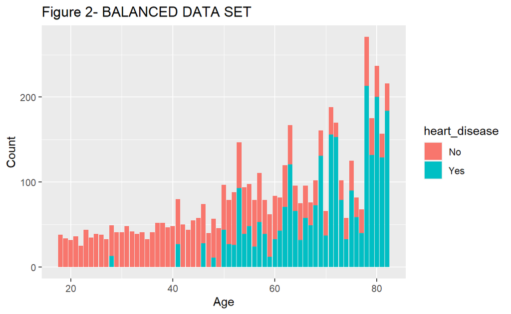

```r
ggplot(HDover, aes(x=age, fill=heart_disease))+
  geom_bar() +
  labs(x="Age", y="Count", title = "Figure 2- BALANCED DATA SET")
```

### Recode binary variables to “YES” or “NO” for clarity

```r
HDover<-mutate(HDover, hypertension = recode(hypertension, `1` = "Yes", `0` = "No"))
```

```r
HDover<-mutate(HDover, stroke = recode(stroke, `1` = "Yes", `0` = "No"))
```